# Impacto económico y de salubridad que dejó el Covid-19 a los estudiantes de UTEC

## **Estado~Tratamiento**

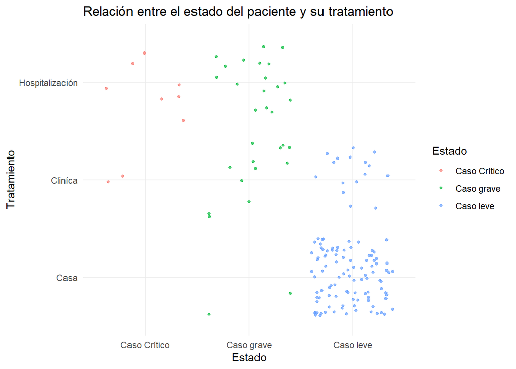

```r
Estado <- DFN$Estado
Tratamiento <- DFN$Tratamiento
ggplot(data = NULL, aes(x = Estado, y = Tratamiento)) +
  geom_jitter(aes(color = Estado), size = 1, alpha = 0.7) +
  xlab('Estado') +
  ylab('Tratamiento') +
  ggtitle('Relación entre el estado del paciente y su tratamiento') +
  theme_minimal()
```

Observamos que para cuando son estados críticos o graves hay una tendencia a preferir la hospitalización, en cambio, para cuando son casos leves se prefiere un tratamiento en la casa. Asimismo, hay una pequeña parte en casos leves que prefieren no ser hospitalizados, o ser llevados a la clínica a fin de ser su tratamiento. Aunque esto nos desvela que los estudiantes UTEC frente al COVID-19 en su mayoría prefieren tomarse cuidados por su cuenta, ya sea en su casa o sin hospitalización, por lo tanto, hay riesgo de que al no seguir un tratamiento médico podría escalar a caso grave o crítico.

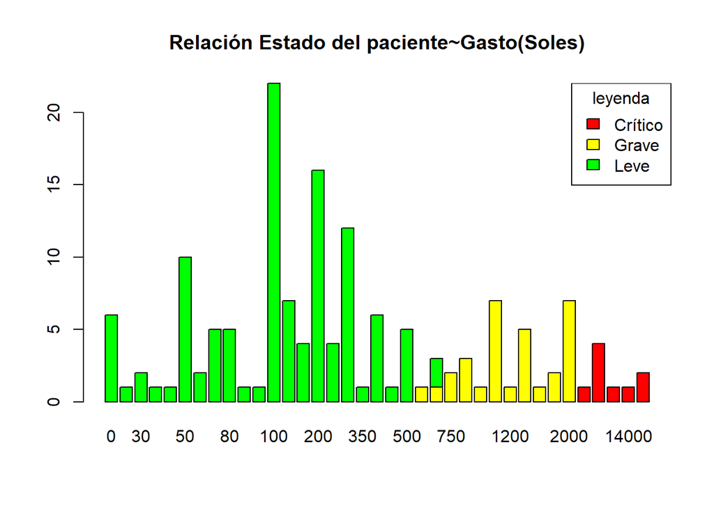

```r
tabgastoyestado<-table(DFN$Estado, DFN$Gasto)
barplot(tabgastoyestado, main="Relación Estado del paciente~Gasto(Soles)",col=c("red","yellow", "green"))

legend(x="topright", legend=c("Crítico","Grave","Leve"),fill = c("red","yellow","green"), title="leyenda")
```

## **Covid Veces~Establecimiento Veces**

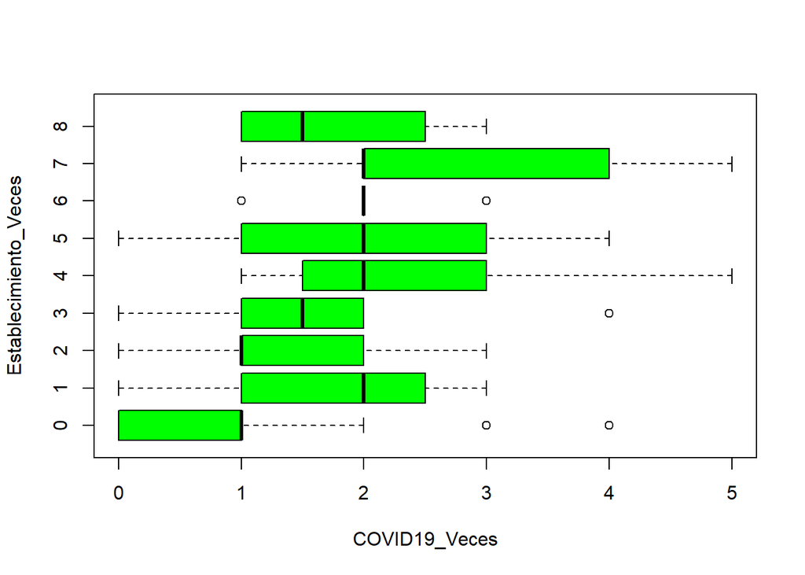

```r
COVID19_Veces <- DFN$COVID19_Veces
Establecimiento_Veces <- DFN$Establecimiento_Veces

tabCyE<-table(COVID19_Veces, Establecimiento_Veces)
boxplot(formula=COVID19_Veces~Establecimiento_Veces, data=DFN,col="green", horizontal = T)
```